# Logistic Regression

Josh Murray

23/01/2022

## Introduction

We used both the `lm()` function and `glm()` function to run linear regression models. We need to use `glm()`, which stands for Generalized Linear Models. We will focus more on GLM’s in our next lecture, but for now we can use it without knowing why we are specifying a link function in addition to a family.

Recall that our logistic regressin is specified as:

$$log\Big(\frac{p(x)}{1-p(x)}\Big) = \boxed{\alpha + \beta_1 x_1 + \dots \beta_p x_p}$$
where using the inverse logit we obtain

$$p(x) =\frac{e^{\alpha + \beta_1 x_1 +\dots + \beta_p x_p}}{1 + e^{\alpha + \beta_1 x_1 +\dots + \beta_p x_p}}$$

R comes equipped with a logit (`qlogis()`) and inverse logit (`plogis()`) function. Here we just assign them to names that are slightly easier to remember.

```r
library(tidyverse)
logit <- qlogis
invlogit <- plogis
```

Let’s simulate some fake data to build a simple model with

```r
set.seed(5657)
simulate_logit_model <- function(sample_size = 100,
                                 alpha = 2, beta = 1) {

x <- rnorm(sample_size)
linear_terms = alpha + beta * x

probability <- invlogit(linear_terms)
y <- rbinom(sample_size, 1, probability)
return(data.frame(x, y))
}

alpha <- -1.40
beta <- 2.33
fake_data <- simulate_logit_model(200, alpha, beta)
dim(fake_data)
```

```
## [1] 200   2
```

```r
head(fake_data)
```

```
##            x y
## 1 -0.9260565 0
## 2 -2.2790289 0
## 3 -0.6405135 1
## 4  1.6589867 1
## 5  0.2802218 0
## 6  0.4151313 1
```

Let’s fit a basic model with glm

```r
fit <- glm(y ~ x, family=binomial(link="logit"), data=fake_data)

summary(fit)
```

```
##
## Call:
## glm(formula = y ~ x, family = binomial(link = "logit"), data = fake_data)
##
## Deviance Residuals:
##     Min       1Q   Median       3Q      Max
## -1.7204  -0.7557  -0.3840   0.7275   2.5356
##
## Coefficients:
##             Estimate Std. Error z value Pr(>|z|)
## (Intercept)  -1.0381     0.1997  -5.197 2.03e-07 ***
## x             1.6979     0.2651   6.404 1.52e-10 ***
## ---
## Signif. codes:  0 '***' 0.001 '**' 0.01 '*' 0.05 '.' 0.1 ' ' 1
##
## (Dispersion parameter for binomial family taken to be 1)
##
##     Null deviance: 256.41  on 199  degrees of freedom
## Residual deviance: 190.32  on 198  degrees of freedom
## AIC: 194.32
##
## Number of Fisher Scoring iterations: 5
```

Remember that there is no analytical solution for the coefficients in a logistic regression (as compared to OLS). We can check for convergence, however warnings will be displayed if there were issues during the model fitting process

```r
# did the model converge
fit$converged
```

```
## [1] TRUE
```

```r
# how many iterations
fit$iter
```

```
## [1] 5
```

Let’s plot the estimated logistic curve against the population curve.

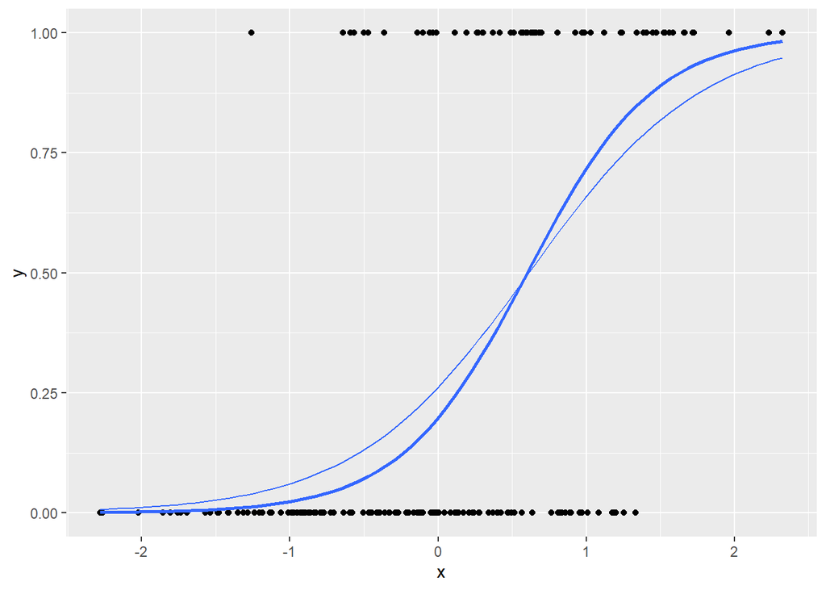

```r
fake_data <- fake_data %>%
  mutate(population_pr = invlogit(alpha + beta*x))

fake_data %>%
  ggplot(aes(x, y)) +
  geom_point() +
  stat_smooth(method="glm", se=F,
              method.args = list(family=binomial),
              size = .5)+
  stat_smooth(aes(x, population_pr), method="glm", se=F,
              method.args = list(family=binomial),
              size = 1)
```

The thick blue line shows the population curve we would expect while the thinner blue line is the simulated curve. Let’s run this simulation 500 times.

```r
n_sim <- 500

sim_data <- purrr::map_df(1:n_sim, function(iter) {
  fake_data <- simulate_logit_model(200, alpha, beta)%>%
  mutate(population_pr = invlogit(alpha + beta*x)) %>%
    mutate(sim = paste0("sim_", iter)) %>%
    as_tibble()
  return(fake_data)
})

sim_data %>%
  count(sim)
```

```
## # A tibble: 500 x 2
##    sim         n
##    <chr>   <int>
##  1 sim_1     200
##  2 sim_10    200
##  3 sim_100   200
##  4 sim_101   200
##  5 sim_102   200
##  6 sim_103   200
##  7 sim_104   200
##  8 sim_105   200
##  9 sim_106   200
## 10 sim_107   200
## # ... with 490 more rows
```

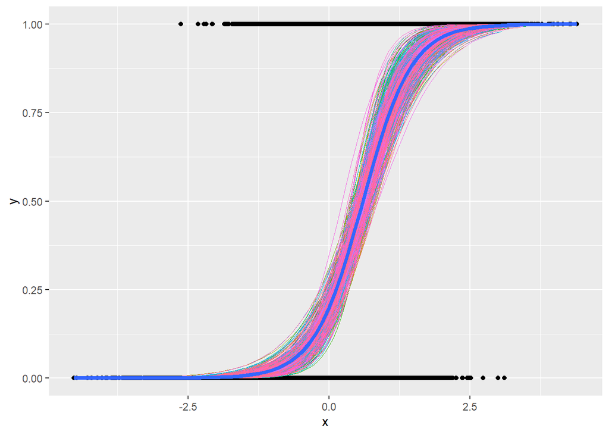

```r
sim_data %>%
  ggplot(aes(x, y)) +
  geom_point() +
  stat_smooth(aes(color=sim),method="glm", se=F,
              method.args = list(family=binomial),
              size = .25)+
  stat_smooth(aes(x, population_pr), method="glm", se=F,
              method.args = list(family=binomial),
              size = 1.5) +
  guides(color="none")
```

We can also fit a logistic regression for each simulation.

But first a quick aside on using broom. The [`broom` package](https://cran.r-project.org/web/packages/broom/vignettes/broom.html) takes messy output from commonly used R model fitting functions and transforms it into a tidy format. For example:

```r
library(broom)
model_fit <- glm(y ~ x, family=binomial(link="logit"), data=fake_data)

tidy(model_fit)
```

```
## # A tibble: 2 x 5
##   term        estimate std.error statistic  p.value
##   <chr>          <dbl>     <dbl>     <dbl>    <dbl>
## 1 (Intercept)    -1.04     0.200     -5.20 2.03e- 7
## 2 x               1.70     0.265      6.40 1.52e-10
```

This puts the coefficients along with their standard errors, test statistics and p-values into a `tibble.` You can also request confidence intervals which makes for easy plotting.

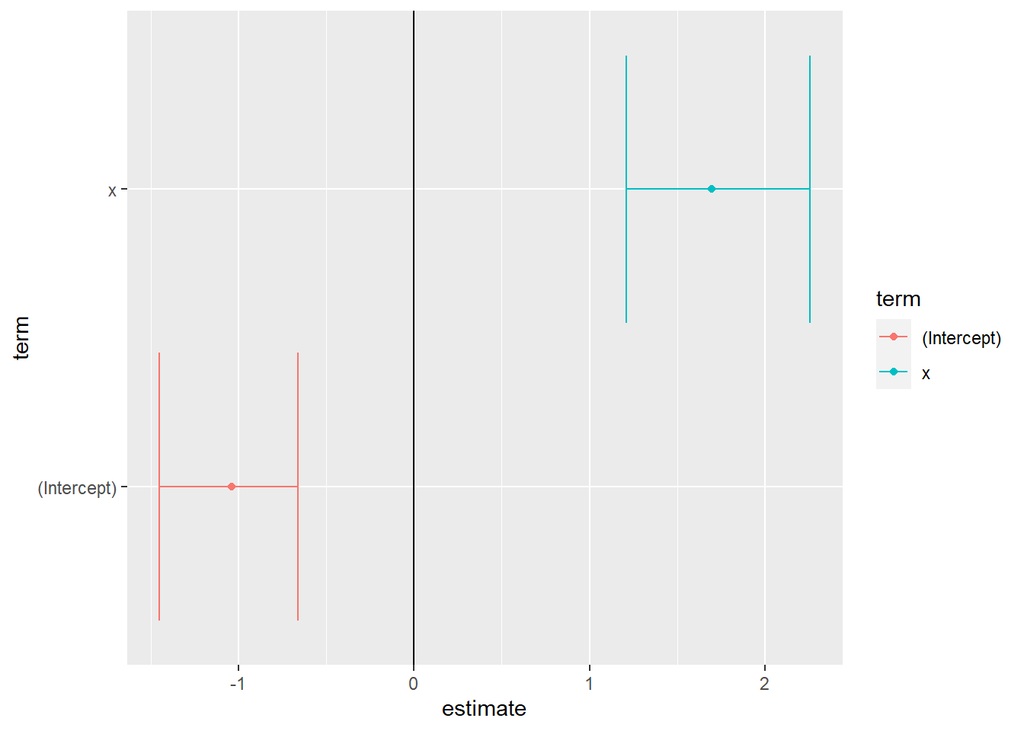

```r
tidy_fit <- tidy(model_fit, conf.int = TRUE)
ggplot(tidy_fit, aes(estimate, term, color = term)) +
    geom_point() +
    geom_errorbarh(aes(xmin = conf.low, xmax = conf.high)) +
    geom_vline(xintercept = 0)
```

For our current task, we can fit a logistic regression model for each of our simulated data sets and store the coefficients in a tidy tibble with just 3 lines of code.

```r
library(broom)
fit_by_sim <- sim_data %>%
  group_by(sim) %>%
  do(tidy(glm(y ~ x, ., family = binomial(link="logit"))))

head(fit_by_sim)
```

```
## # A tibble: 6 x 6
## # Groups:   sim [3]
##   sim     term        estimate std.error statistic  p.value
##   <chr>   <chr>          <dbl>     <dbl>     <dbl>    <dbl>
## 1 sim_1   (Intercept)    -1.64     0.293     -5.60 2.10e- 8
## 2 sim_1   x               3.03     0.458      6.62 3.50e-11
## 3 sim_10  (Intercept)    -1.37     0.242     -5.67 1.43e- 8
## 4 sim_10  x               2.38     0.354      6.73 1.69e-11
## 5 sim_100 (Intercept)    -1.23     0.230     -5.33 1.00e- 7
## 6 sim_100 x               2.07     0.306      6.78 1.18e-11
```

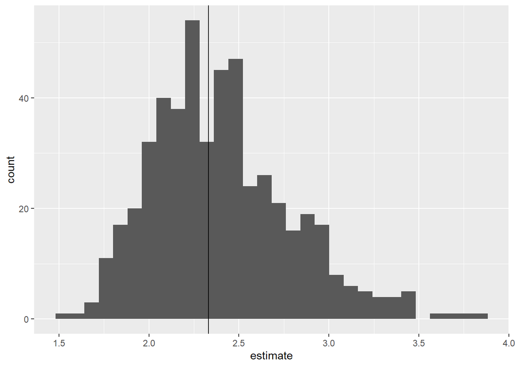

```r
fit_by_sim %>%
  filter(term == 'x') %>%
  ggplot(aes(estimate)) +
    geom_histogram() +
    geom_vline(xintercept = beta) # the population value
```

Similar to our linear regression framework, we can estimate model where the effects of our coefficients aren’t strictly increasing or descreasing. For example, in a hospital setting, it’s often the case that both high and low values of a laboratory result are associated with a poor outcome. Let’s simulate this scenario below and plot the fitted curve.

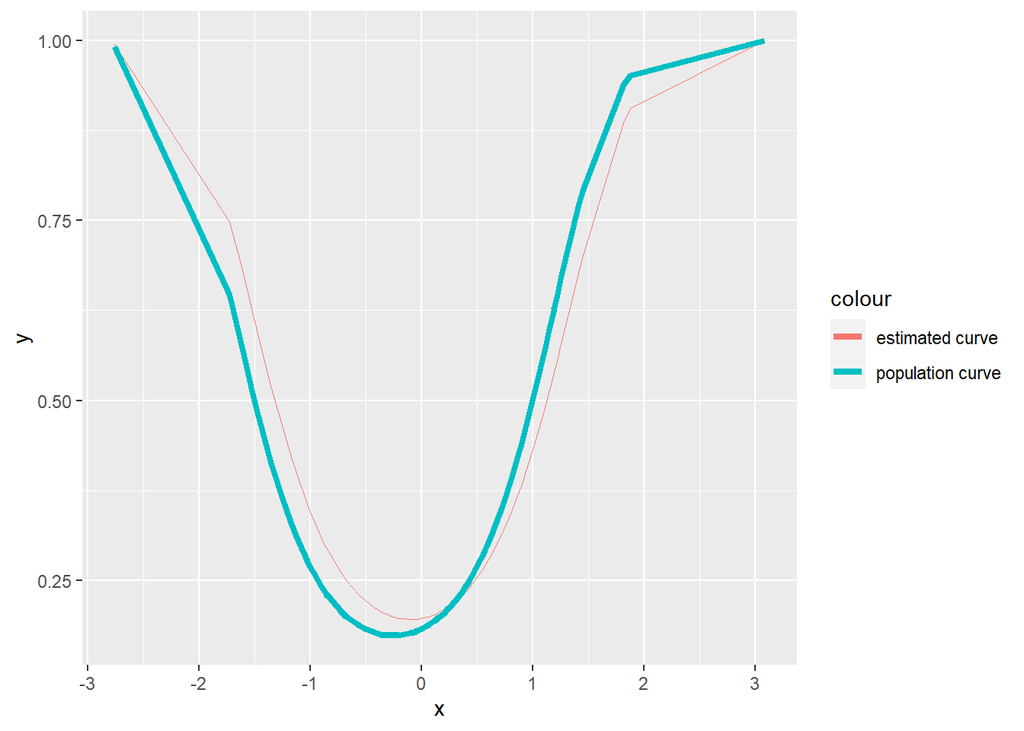

```r
sim_nonlinear_data = function(sample_size = 100, alpha = -1.5 , beta = .5) {
  x = rnorm(n = sample_size)
  linear_terms <-  alpha + beta * x + x ^ 2
  probability <- invlogit(linear_terms)
  y = rbinom(n = sample_size, size = 1, prob = probability)
  return(tibble(y, x))
}

sim_data2 <- sim_nonlinear_data()
model_fit <- glm(y ~ x + I(x^2), data = sim_data2, family = binomial)

sim_data2 <- sim_data2 %>%
  mutate(predicted_value = predict(model_fit, ., type = "response"),
         population_value = invlogit(-1.5 + .5*x + x^2))

sim_data2 %>%
  ggplot(aes(x, y)) +
   geom_line(aes(x, predicted_value, color = 'estimated curve'),
              size = .25) +
  geom_line(aes(x, population_value, color = 'population curve'),
              size = 1.5)
```

## Example with the NES data

The NES data contains presedential voting preferences along with demographics for a sample of americans for every election from 1952 to 2000.

```r
nes <- read.table('data/nes.txt', header=TRUE)

DT::datatable(head(nes), options = list(scrollX=T))
```

|  | year | resid | weight1 | weight2 | weight3 | age | gender | race | educ1 | urban | region | income | occup1 | union | religion | educ2 | educ3 | martial_status | occup2 | icpsr_cty | fips_cty | partyid7 | partyid3 | partyid3_b | str_partyid | father_party | mother_party | dlikes | rlikes | … |
| --- | --- | --- | --- | --- | --- | --- | --- | --- | --- | --- | --- | --- | --- | --- | --- | --- | --- | --- | --- | --- | --- | --- | --- | --- | --- | --- | --- | --- | --- | --- |
| 536 | 1952 | 1 | 1 | 1 | 1 | 25 | 2 | 1 | 2 | 2 | 1 | 4 | 2 | 1 | 1 | 3 | 3 | 1 | 2 |  |  | 6 | 3 | 3 | 3 | 3 | 3 | 0 | 1 | … |
| 537 | 1952 | 2 | 1 | 1 | 1 | 33 | 2 | 1 | 1 | 2 | 1 | 4 | 6 | 1 | 1 | 1 | 1 | 1 | 6 |  |  | 5 | 3 | 3 | 2 | 2 | 2 | -1 | 3 | … |
| 538 | 1952 | 3 | 1 | 1 | 1 | 26 | 2 | 1 | 2 | 2 | 1 | 3 | 6 | 2 | 2 | 3 | 3 | 1 | 6 |  |  | 4 | 2 | 2 | 1 | 1 | 1 | 0 | 5 | … |
| 539 | 1952 | 4 | 1 | 1 | 1 | 63 | 1 | 1 | 2 | 2 | 1 | 3 | 3 | 1 | 1 | 2 | 2 | 1 | 3 |  |  | 7 | 3 | 3 | 4 | 1 |  | -1 | 3 | … |
| 540 | 1952 | 5 | 1 | 1 | 1 | 66 | 2 | 1 | 2 | 2 | 2 | 1 | 6 | 2 | 1 | 4 | 4 | 1 | 6 |  |  | 7 | 3 | 3 | 4 | 1 | 1 | -2 | 0 | … |
| 541 | 1952 | 6 | 1 | 1 | 1 | 48 | 2 | 1 | 2 | 2 | 2 | 4 | 6 | 1 | 1 | 2 | 2 | 1 | 6 |  |  | 3 | 1 | 1 | 2 | 1 | 1 | 0 | 4 | … |

### A simple model

Here we fit a simple model for the probability of viting republican on a subset of the (year = 1992) using income and age as our inputs.

```r
nes_1992 <- nes %>%
  filter(year == 1992)
fit_1992 <- glm(rvote ~ income + age, family=binomial(link="logit"), data=nes_1992)

coef(summary(fit_1992))
```

```
##                 Estimate  Std. Error   z value     Pr(>|z|)
## (Intercept) -1.803227069 0.274554355 -6.567833 5.105286e-11
## income       0.285924583 0.056290826  5.079417 3.785948e-07
## age          0.006171748 0.003509058  1.758805 7.861068e-02
```

We can also get confidence intervals using a similar method as we did for linear regression

```r
confint(fit_1992, level = 0.95)
```

```
##                     2.5 %      97.5 %
## (Intercept) -2.3481344188 -1.27115073
## income       0.1765052576  0.39730390
## age         -0.0007043198  0.01305961
```

We can add in interactions with the `:` syntax.

```r
nes_1992 <- nes %>%
  filter(year == 1992)
fit_1992 <- glm(rvote ~ income + age + income:age, family=binomial(link="logit"), data=nes_1992)

coef(summary(fit_1992))
```

```
##                 Estimate  Std. Error    z value     Pr(>|z|)
## (Intercept) -2.092090301 0.543103698 -3.8521010 0.0001171087
## income       0.385197256 0.169994717  2.2659366 0.0234552639
## age          0.011831828 0.009775217  1.2103903 0.2261291543
## income:age  -0.002008822 0.003235597 -0.6208504 0.5346980293
```

### Odds ratios

Remember we can compute odds ratios by exponentiating the coefficients from our models. Here we show that we get the same result by doing that as calculating by hand.

Let’s look at differences in gender for supporting either Bush or Clinton in 1992.

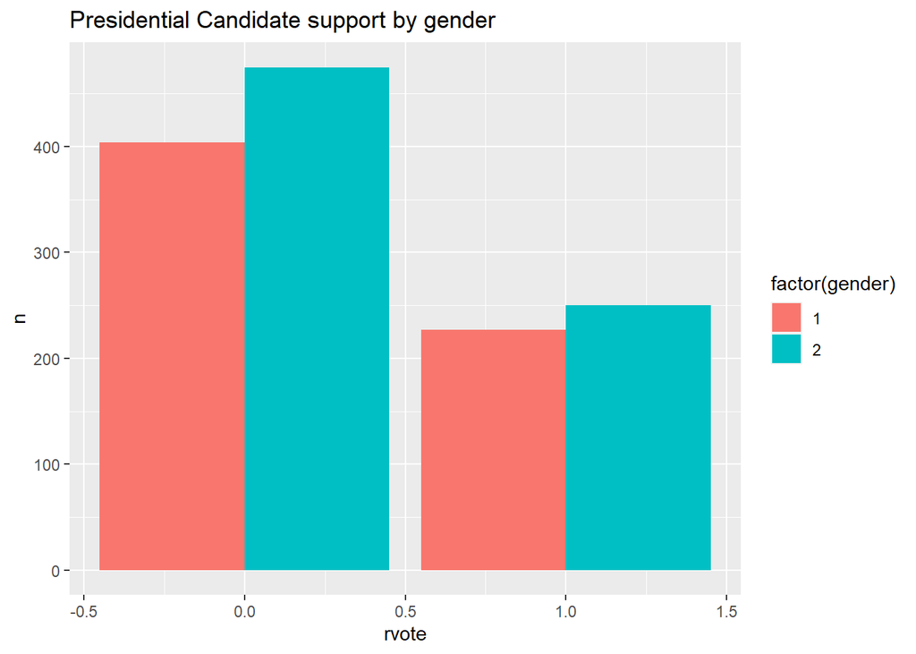

```r
# gender = 0 for male
# gender = 1 for female

nes_1992 %>%
  count(gender, rvote ) %>%
  ggplot(aes(rvote, n, fill = factor(gender) )) +
  geom_bar(stat = "identity", position='dodge') +
  ggtitle("Presidential Candidate support by gender")
```

```r
table(nes_1992$gender, nes_1992$rvote)
```

```
##
##       0   1
##   1 404 227
##   2 475 250
```

It seems those who responded with female as their gender tend to support the republican candidate less often. Let’s calculate the odds ratio

```r
tab <- table(nes_1992$gender, nes_1992$rvote)
knitr::kable(tab)
```

| 0 | 1 |
| --- | --- |
| 404 | 227 |
| 475 | 250 |

```r
female_republican_odds <- (tab[2,2]/(tab[2,2] + tab[2,1]))/(tab[2,1]/(tab[2,2] + tab[2,1]) )

male_republican_odds <- (tab[1,2]/(tab[1,2] + tab[1,1]))/(tab[1,1]/(tab[1,1] + tab[1,2]) )


or <- female_republican_odds/male_republican_odds


gender_model <-  glm(rvote ~ gender, data = nes_1992,
                   family = binomial(link = "logit"))



print(female_republican_odds)
```

```
## [1] 0.5263158
```

```r
print(male_republican_odds)
```

```
## [1] 0.5618812
```

```r
print(or)
```

```
## [1] 0.936703
```

```r
summary(gender_model)
```

```
##
## Call:
## glm(formula = rvote ~ gender, family = binomial(link = "logit"),
##     data = nes_1992)
##
## Deviance Residuals:
##     Min       1Q   Median       3Q      Max
## -0.9443  -0.9443  -0.9196   1.4299   1.4592
##
## Coefficients:
##             Estimate Std. Error z value Pr(>|z|)
## (Intercept) -0.51108    0.18338  -2.787  0.00532 **
## gender      -0.06539    0.11396  -0.574  0.56609
## ---
## Signif. codes:  0 '***' 0.001 '**' 0.01 '*' 0.05 '.' 0.1 ' ' 1
##
## (Dispersion parameter for binomial family taken to be 1)
##
##     Null deviance: 1758.8  on 1355  degrees of freedom
## Residual deviance: 1758.5  on 1354  degrees of freedom
##   (368 observations deleted due to missingness)
## AIC: 1762.5
##
## Number of Fisher Scoring iterations: 4
```

```r
coef(gender_model)[2]
```

```
##      gender
## -0.06538903
```

```r
exp(coef(gender_model)[2])
```

```
##   gender
## 0.936703
```

## Logistic regression as a classifier

## Evaluating the performance of a logistic regression

So far we have looked at the output of a logistic regression model as a probability. In a predictive setting, we often want to use these probabilities to make some kind of decision. That is, we want to use the probabilities classify the output into 1 of 2 labels. In our running example, we may want to build a model to predict which candidate a potential voter will vote for and use that information to target people for donations.

If we use our model so far, we could make one of two potential errors:

- Predict that a voter will vote for Bush when they voted for Clinton
- Predict that a voter will vote for Clinton when they voted for Bush

Let’s continue on with our example, by adding a few more predictor variables and try to use it to determine who a potential voter will vote for (in 1992).

```r
# select the variables we wish to examine
nes_1992 <- nes_1992 %>%
  dplyr::select(rvote , age, income, educ1, race , income, religion)

# remove missing values
nes_1992 <- nes_1992 %>%
  filter(complete.cases(nes_1992))

# split data into training and testing sets

set.seed(13453)
n <- nrow(nes_1992)
training_size <- .8
split <- sample(1:nrow(nes_1992), floor(n*training_size), replace = F)

train_df <- nes_1992 %>%
  slice(split)

test_df <- nes_1992 %>%
  slice(-split)


final_model <- glm(rvote ~ income + age + educ1 + factor(race) + factor(religion)
                      , data = train_df, family = binomial)
```

## Model evaluation

A common way to evaluate the performance of a classification task is through a confusion matrix as follows:

```r
perf <- matrix(c("a", "b", "c", "d"), nrow = 2)

rownames(perf) <- c("Predicted No", "Predicted Yes")
colnames(perf) <- c("Actual No", "Actual Yes")

knitr::kable(perf)
```

|  | Actual No | Actual Yes |
| --- | --- | --- |
| Predicted No | a | c |
| Predicted Yes | b | d |

So in our example in words:

- *Sensitivity* is the percentage of people who voted for Bush that the model identifies
- *Specificity* is the percentage of people who voted for Clinton that the model identifies
- *Positive Predictive Value* is the percentage of the time that a voter will vote for Bush when the model predicts that a voter will vote for Bush
- *Negative Predictive Value* is the percentage of the time that a voter will vote for Clinton when the model predicts that a voter will vote for Clinton

```r
train_df <- train_df %>%
  mutate(prediction = predict(final_model, train_df, type = "response"))

cut_off <- .5


train_df <- train_df %>%
  mutate(prediction_class = ifelse(prediction > cut_off, 1, 0))

tab <- table(train_df$prediction_class, train_df$rvote)

colnames(tab) <- c("Voted Clinton", "Voted Bush")
rownames(tab) <- c("Predicted Clinton", "Predicted Bush")

knitr::kable(tab)
```

|  | Voted Clinton | Voted Bush |
| --- | --- | --- |
| Predicted Clinton | 605 | 242 |
| Predicted Bush | 94 | 142 |

```r
sensitivity <- round(tab[2,2]/(tab[1,2] +tab[2,2]), 3)
specificity <- round(tab[1,1]/(tab[1,1] +tab[2,1]), 3)
ppv <- round(tab[2,2]/(tab[2,1] +tab[2,2]), 3)
npv <- round(tab[1,1]/(tab[1,1] +tab[1,2]), 3)

df <- tibble(sensitivity = sensitivity,
             specificity = specificity,
             ppv = ppv,
             npv = npv)

DT::datatable(df, caption = "Voter Model results on training data (cut-off = .5)")
```

|  | sensitivity | specificity | ppv | npv |
| --- | --- | --- | --- | --- |
| 1 | 0.37 | 0.866 | 0.602 | 0.714 |

We could try a different cut-off value and obtain different results

```r
cut_off <- .7


train_df <- train_df %>%
  mutate(prediction_class = ifelse(prediction > cut_off, 1, 0))

tab <- table(train_df$prediction_class, train_df$rvote)

colnames(tab) <- c("Voted Clinton", "Voted Bush")
rownames(tab) <- c("Predicted Clinton", "Predicted Bush")

knitr::kable(tab)
```

|  | Voted Clinton | Voted Bush |
| --- | --- | --- |
| Predicted Clinton | 697 | 377 |
| Predicted Bush | 2 | 7 |

```r
sensitivity <- round(tab[2,2]/(tab[1,2] +tab[2,2]), 3)
specificity <- round(tab[1,1]/(tab[1,1] +tab[2,1]), 3)
ppv <- round(tab[2,2]/(tab[2,1] +tab[2,2]), 3)
npv <- round(tab[1,1]/(tab[1,1] +tab[1,2]), 3)

df <- tibble(sensitivity = sensitivity,
             specificity = specificity,
             ppv = ppv,
             npv = npv)

DT::datatable(df, caption = "Voter Model results on training data(cut-off=.7)")
```

|  | sensitivity | specificity | ppv | npv |
| --- | --- | --- | --- | --- |
| 1 | 0.018 | 0.997 | 0.778 | 0.649 |

We can get different performance by varying the metrics

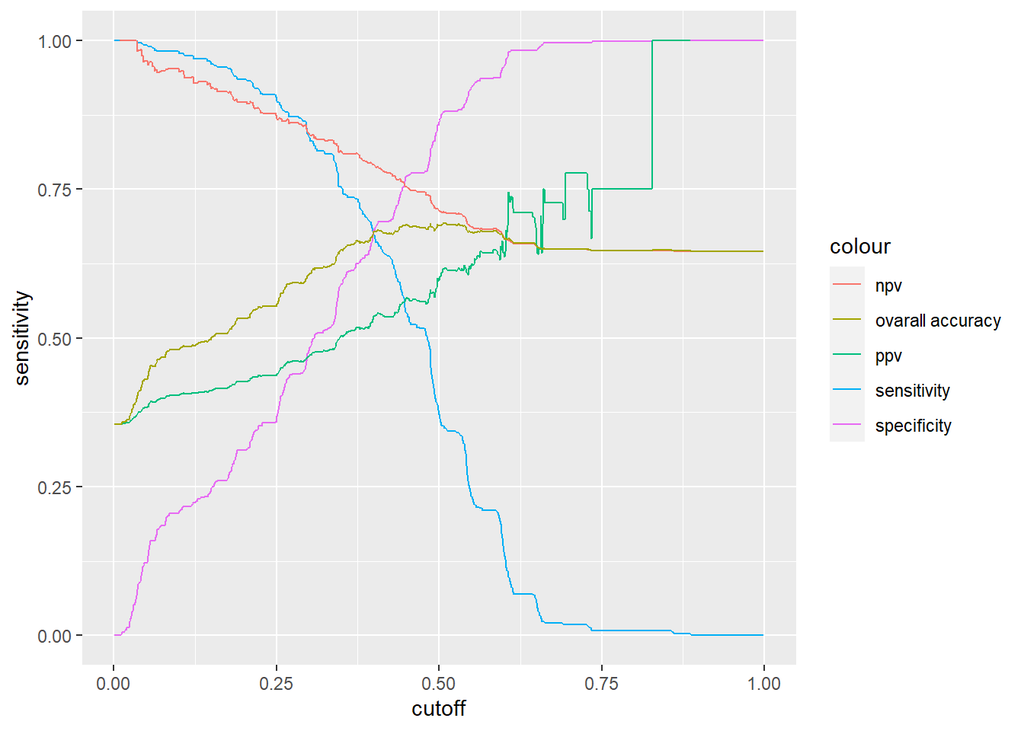

```r
cutoffs <- seq(0.001, 0.999, length.out = 1000)

performance <- list()

for(i in cutoffs) {
  train_df <- train_df %>%
  mutate(prediction_class = factor(ifelse(prediction > i, 1, 0), levels= c(0,1))) %>%
  mutate(presvote_binary = factor(rvote, levels = c(0,1)))

tab <- table(train_df$prediction_class, train_df$rvote)


sensitivity <- round(tab[2,2]/(tab[1,2] +tab[2,2]), 3)
specificity <- round(tab[1,1]/(tab[1,1] +tab[2,1]), 3)
ppv <- round(tab[2,2]/(tab[2,1] +tab[2,2]), 3)
npv <- round(tab[1,1]/(tab[1,1] +tab[1,2]), 3)
ovarall_accuracy <- (tab[1,1] + tab[2,2])/sum(tab)

df <- tibble(cutoff = i,
             ovarall_accuracy = ovarall_accuracy,
             sensitivity = sensitivity,
             specificity = specificity,
             ppv = ppv,
             npv = npv)

performance[[as.character(i)]] <- df
}

performance <- do.call(rbind, performance)

performance %>%
  ggplot(aes(cutoff, sensitivity, color = "sensitivity")) +
  geom_line() +
  geom_line(aes(cutoff, specificity, color = "specificity")) +
  geom_line(aes(cutoff, ppv,color = "ppv")) +
  geom_line(aes(cutoff, npv, color = "npv")) +
  geom_line(aes(cutoff, ovarall_accuracy, color = "ovarall accuracy"))
```

### ROC curve

A curve used extensively in practice is the Receiver Operating Characteristics (ROC) curve. The ROC summarizes performance of the model under all thresholds according to two error metrics; True Positive Rate (Sensitivity) and False Positive Rate (1 - specificity).

Below is an ROC curve for the model we fit above.

```r
library(pROC)
rocobj <- roc(train_df$rvote, train_df$prediction)
```

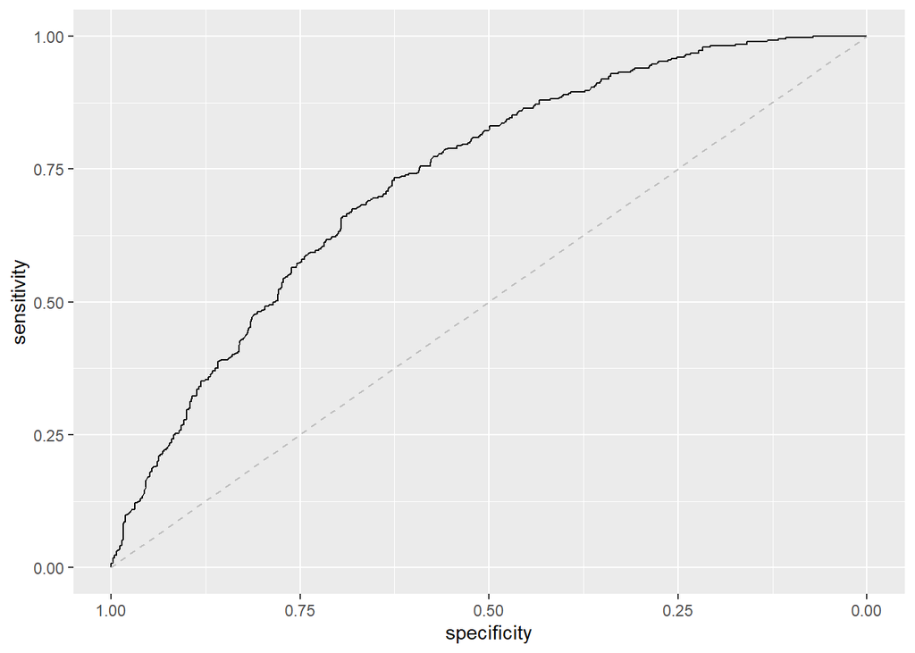

```r
g <- ggroc(rocobj)+
    geom_segment(aes(x = 1, xend = 0, y = 0, yend = 1), color="grey", linetype="dashed")

print(g)
```

The overall performance of a classifier, summarized over all possible thresholds, is given by the area under the ROC curve (or AUC). An AUC of .5 indicates a model that does no better than chance. The ROC for a model with a high AUC usually hugs the top left corner of the graph. Our AUC is 0.76, which is somewhere in between a great model and a model that is no better than chance.

#### Aside on performance metrics

When choosing a threshold, not all error metrics are the same. In our toy example here (predicting who a voter will vote for), the consequences of the model making a mistake are quite low. What if our model was trying to predict patient deterioration in hospital?

Let’s say we defined a classifier that predicts which patients will deteriorate in the next 48 hours and may need a transfer to an ICU. When the model predicts that a patient will deteriorate, it sends an alert message to all doctors and nurses caring for this patient. The clinicians then meet to review the patiet’s status and discuss next steps.

These are the errors we can make

- We can predict a patient will deteriorate, and they don’t
- We can predict that a patient will not deteriorate, and they do

We may say, “We don’t want to miss any patients who deteriorate”, so we pick a threshold that gives us a very high sensitivity. This can unintended consequences. If our PPV is too low because we selected a high sensitivity threshold, the clinicians may get too many alarms and start to feel burnout. They may also stop trusting the alarms all together.

The other situation may be even worse. If we ensure that we have a high PPV, then we may “miss” a bunch of patients who deteriorate. The physicians again will stop trusting the algorithm, and you may not intervene on patients you could have saved.

All this to say that - Non ML/stats experts generally say, give me a model with high accuracy. As we have seen, accuracy can be defined in several different ways. - At the outset of a machine learning project, lay out all of the error metrics and explain to your collaborators the the consequences of each mistake (They may have to explain to you the consequences of each mistake) - Once your collaborators understand what is at stake, you can jointly select performance metrics that satisfies whatever criteria you agree to.